# Rockfall - Previsão de Alcance de Blocos

Data Analysis Step

Felipe Daiha Alves

2022-08-10

# 1 . **Objetivo**:

Relatório da etapa de *data analysis* contendo informações e resultados sobre o processo de **Queda de Blocos** em encostas.

A fonte de dados original foi construída em um **Banco de Dados MySQL** e salvo um *csv* com os dados fundamentais para análise. Para acesso ao dicionário das variáveis, entre em https://github.com/daiha98/rockfall/blob/main/README.md.

# 2 . **Environment & Data Cleaning**:

## 2.1 . **Configurando Ambiente**

```r
# Nome dos pacotes

packages <- c('dplyr', 'tidyr', 'data.table', ## Manipulacao de Dados
              'ggplot2', 'gridExtra', 'scales', 'ggcorrplot' ## Visualizacao de Dados
              )


# Instalando pacotes (caso ainda nao esteja)

installed_packages <- packages %in% rownames(installed.packages())
if (any(installed_packages == FALSE)) {
  install.packages(packages[!installed_packages])
}


# Carregando pacotes

invisible(lapply(packages, library, character.only = TRUE))


# Removendo variavel criada previamente

rm(packages, installed_packages)


# Configuracoes de visualizacao

options(digits = 10, scipen = 999)
```

## 2.2 . **Carregando dados**

```r
# Load da base de dados

df_rcf <- data.table::fread('C:/Users/daiha/OneDrive/Desktop/UFRJ/IC_Emilio/df_rcf_backup.csv', drop = 'V1')


# Visualizacao primaria dos dados

glimpse(df_rcf)
```

```
## Rows: 1,050
## Columns: 11
## $ id               <int> 1, 2, 3, 4, 5, 6, 7, 8, 9, 10, 11, 12, 13, 14, 15, 16…
## $ h_enc            <int> 5, 5, 5, 5, 5, 5, 5, 5, 5, 5, 5, 5, 5, 5, 5, 5, 5, 5,…
## $ ang_enc          <int> 50, 50, 50, 50, 50, 50, 50, 50, 50, 50, 50, 50, 50, 5…
## $ h_rmp            <lgl> NA, NA, NA, NA, NA, NA, NA, NA, NA, NA, NA, NA, NA, N…
## $ ang_rmp          <lgl> NA, NA, NA, NA, NA, NA, NA, NA, NA, NA, NA, NA, NA, N…
## $ rock_mass        <int> 85000, 85000, 85000, 85000, 85000, 85000, 167000, 167…
## $ vel_rad          <int> 0, 1, 2, 3, 4, 5, 0, 1, 2, 3, 4, 5, 0, 1, 2, 3, 4, 5,…
## $ mean_range       <dbl> 6.60665, 6.70712, 6.94760, 7.35773, 7.89524, 8.54660,…
## $ porc_ac          <dbl> 0.633, 0.492, 0.233, 0.034, 0.001, 0.000, 0.614, 0.46…
## $ porc_disp        <dbl> 0.367, 0.508, 0.767, 0.966, 0.993, 0.873, 0.386, 0.53…
## $ porc_rock_mapped <dbl> 1.000, 1.000, 1.000, 1.000, 0.994, 0.873, 1.000, 1.00…
```

## 2.3 . **Tratamento de dados**

Como os dados foram construídos no MySQL, essa etapa apenas serve para validação da consistência final do dataset.

**Analisando NAs**

```r
# Checando NAs na base

sapply(df_rcf, function(x) sum(is.na(x)))
```

```
##               id            h_enc          ang_enc            h_rmp
##                0                0                0             1050
##          ang_rmp        rock_mass          vel_rad       mean_range
##             1050                0                0                0
##          porc_ac        porc_disp porc_rock_mapped
##                0                0                0
```

*Comments*: 2 colunas estao completamente vazias, entao droparemos da base final. Alem disso, ha colunas cujo tipo do dado esta equivocado, por isso iremos alterar.

**Alterando tipo e dropando variaveis NA**

```r
# Alterando tipos das variaveis e limpando df de features indesejadas

df_rcf <- df_rcf %>%
  dplyr::mutate(h_enc = as.integer(h_enc),
                rock_mass = as.integer(rock_mass)) %>% ### Alterando classes 'num' para 'int' quando necessarias
  dplyr::select(!c(h_rmp, ang_rmp)) ### Removendo colunas totalmente NA
```

**Verificando classes das variaveis**

```r
# Verificando classes das variaveis

lapply(df_rcf %>%
         dplyr::select(where(is.integer)) %>%
         dplyr::select(!c(id)),
       table)
```

```
## $h_enc
##
##   5  10  20  50 100
## 210 210 210 210 210
##
## $ang_enc
##
##  50  60  70  80  90
## 210 210 210 210 210
##
## $rock_mass
##
##   85000  167000  288000  458000  973000 2307000 2370000 3664000
##     150     150     150     150     150     147       3     150
##
## $vel_rad
##
##   0   1   2   3   4   5
## 175 175 175 175 175 175
```

*Comments*: Variavel rock_mass tem 3 registros que foram inseridos de forma indevida… tratar 2370000 == 2307000, pois é como deveria vir na base de dados original.

```r
# Tratando classe rock_mass com dados inseridos indevidamente

df_rcf <- df_rcf %>%
  dplyr::mutate(rock_mass = as.integer(ifelse(rock_mass == 2370000, 2307000, rock_mass)))
      ### Se registro for o erro, tratar. Caso contrario, mantenha o dado original
```

# 3 . **Análise Exploratória**:

## 3.1 . **Distribuição da Área Crítica**

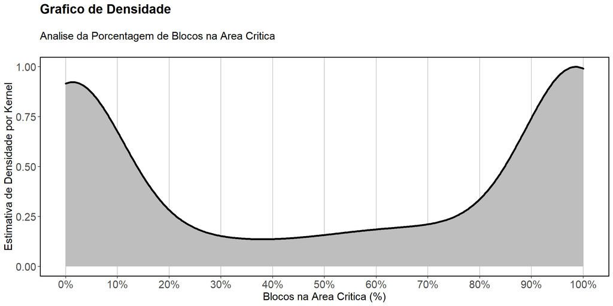

```r
# Plot do grafico de densidade para analise das distribuicoes de AC

ggplot2::ggplot(df_rcf, aes(x = porc_ac)) +
  ggplot2::geom_density(aes(y = ..scaled..), colour = 'black', fill = 'grey', size = 1.25) +
  ggplot2::scale_x_continuous(labels = scales::percent, breaks = seq(from = 0, to = 1, by = 0.1)) +
  ggplot2::xlab('Blocos na Area Critica (%)') +
  ggplot2::ylab('Estimativa de Densidade por Kernel') +
  ggplot2::labs(title = "Grafico de Densidade",
                subtitle = "\nAnalise da Porcentagem de Blocos na Area Critica\n") +
  ggplot2::theme(panel.background = element_rect(fill = "white"),
                 panel.grid.major.x = element_line(colour = "grey"),
                 plot.title = element_text(size = 18.0, face = "bold"),
                 plot.subtitle = element_text(size = 15.0),
                 panel.border = element_rect(colour = "black", fill = NA, size = 1),
                 axis.text.x = element_text(angle = 0, size = 15.0),
                 axis.text.y = element_text(size = 15.0),
                 axis.title.x = element_text(size = 15.0),
                 axis.title.y = element_text(size = 15.0))
```

*Comments*: Estimativa de Densidade por Kernel e uma forma não-paramétrica para estimar a Função densidade de probabilidade de uma variável aleatória, ou seja, é uma função que descreve a verossimilhanca de uma variavel aleatória tomar um valor dado. É uma forma melhor de visualizar a verdadeira densidade da populacao de variaveis continuas do que histogramas.  
O grafico nos mostra a tendência dos dados em convergir para as caudas. Isso nos diz que possivelmente o modelo da CPRM e sensível e volátil a variações dentro dos seus parâmetros, algo questionavel.

## 3.2 . **Matrix de Correlação**

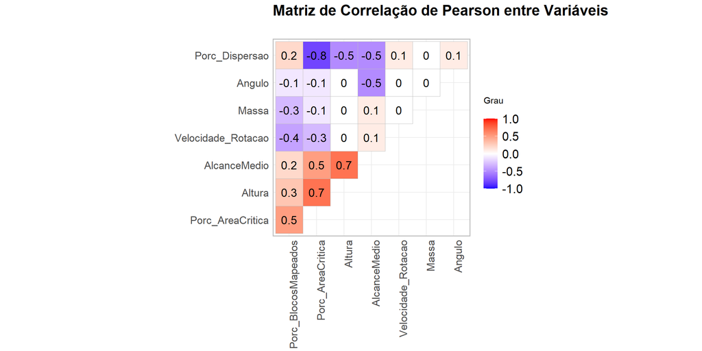

```r
# Criando uma matrix de Correlacao de pearson e plotando a matrix e ajustes no grafico

ggcorrplot::ggcorrplot(corr = as.data.frame(stats::cor(df_rcf %>%
                                                         dplyr::select(!c(id)) %>%
                                                         dplyr::select(Altura = h_enc, Angulo = ang_enc,
                                                                       Massa = rock_mass,
                                                                       Velocidade_Rotacao = vel_rad,
                                                                       AlcanceMedio = mean_range,
                                                                       Porc_AreaCritica = porc_ac,
                                                                       Porc_Dispersao = porc_disp,
                                                                       Porc_BlocosMapeados = porc_rock_mapped) %>%
                                                         tidyr:: drop_na()), method = "pearson",
                                            use = "complete.obs"),
                       lab_size = 5,
                       type = "upper",
                       hc.order = TRUE,
                       lab = TRUE,
                       title = "Matriz de Correlação de Pearson entre Variáveis\n",
                       legend.title = "\nGrau\n",
                       digits = 1) +
 ggplot2:: theme(legend.text = element_text(size = 15.0),
                 axis.text.x = element_text(size = 13, angle = 90),
                 axis.text.y = element_text(size = 13),
                  plot.title = element_text(size = 18.0, face = "bold"),
                 panel.border = element_rect(colour = "grey", fill = NA, size = 1))
```

*Comments*: Podemos visualizar que dentre as principais variáveis previamente ao processo de queda de blocos conhecidas (Exp.: Altura; Ângulo; Massa dos Blocos e Velocidade de Rotação Estimada).

A altura apresenta uma forte correlação positiva com o alcance médio, enquanto que o ângulo de inclinação da encosta mostra uma correlação negativa moderada com o mesmo. O restante das variáveis conhecidas no momento da simulação não apresentam correlação.

As demais variáveis são cálculos a partir do target. Portanto, não são discriminantes em um eventual processo de Machine Learning.

## 3.3 . **Frequencia Faixa de Áreas Críticas x Variáveis Topográficas**

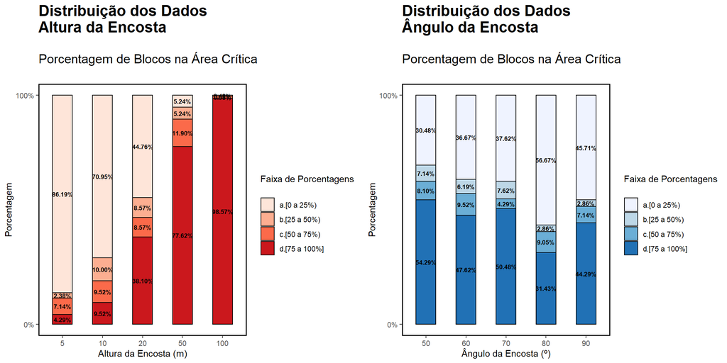

```r
# Promovendo uma classificacao para as Areas Criticas:

df_rcf <- df_rcf %>%
  dplyr::mutate(Faixa_BlocosAC = cut(porc_ac,
                                     breaks = c(0.000, 0.25, 0.500, 0.750, Inf),
                                     labels = c("a.[0 a 25%)",
                                                "b.[25 a 50%)",
                                                "c.[50 a 75%)",
                                                "d.[75 a 100%]"),
                                     right = FALSE))


# Plotando visoes de Faixa de Area Critica x Variaveis Topograficas

    ## 1 - Altura da Encosta

    ggFaixas_hEnc <- ggplot2::ggplot(df_rcf, aes(x = as.factor(h_enc), fill = as.factor(Faixa_BlocosAC))) +
      ggplot2::geom_bar(width = 0.5, colour = "black", aes(y=..count../tapply(..count.., ..x.. ,sum)[..x..],
                                                           fill = factor(Faixa_BlocosAC))) +
      ggplot2::scale_y_continuous(labels = scales::percent, breaks = c(0, 1)) +
      ggplot2::scale_fill_brewer(palette = "Reds") +
      ggplot2::xlab('Altura da Encosta (m)') +
      ggplot2::ylab('Porcentagem') +
      ggplot2::labs(title = "Distribuição dos Dados\nAltura da Encosta",
                    subtitle = "\nPorcentagem de Blocos na Área Crítica\n",
                    fill = "\nFaixa de Porcentagens\n") +
      ggplot2::geom_text(aes(label=scales::percent(..count../tapply(..count.., ..x.. ,sum)[..x..]),
                             y=..count../tapply(..count.., ..x.. ,sum)[..x..]),
                         stat = "count",
                         position = position_stack(vjust = .5),
                         colour = "black",
                         size = 2.5,
                         fontface = "bold") +
      ggplot2::theme(panel.background = element_rect(fill = "white"),
                     plot.title = element_text(size = 18, face = "bold"),
                     plot.subtitle = element_text(size = 15.0),
                     panel.border = element_rect(colour = "black", fill = NA, size = 1))

    ## 2 - Angulo da Encosta

    ggFaixas_angEnc <- ggplot2::ggplot(df_rcf, aes(x = as.factor(ang_enc), fill = as.factor(Faixa_BlocosAC))) +
      ggplot2::geom_bar(width = 0.5, colour = "black", aes(y=..count../tapply(..count.., ..x.. ,sum)[..x..],
                                                           fill = factor(Faixa_BlocosAC))) +
      ggplot2::scale_y_continuous(labels = scales::percent, breaks = c(0, 1)) +
      ggplot2::scale_fill_brewer(palette = "Blues") +
      ggplot2::xlab('Ângulo da Encosta (º)') +
      ggplot2::ylab('Porcentagem') +
      ggplot2::labs(title = "Distribuição dos Dados\nÂngulo da Encosta",
                    subtitle = "\nPorcentagem de Blocos na Área Crítica\n",
                    fill = "\nFaixa de Porcentagens\n") +
      ggplot2::geom_text(aes(label=scales::percent(..count../tapply(..count.., ..x.. ,sum)[..x..]),
                             y=..count../tapply(..count.., ..x.. ,sum)[..x..]),
                         stat = "count",
                         position = position_stack(vjust = .5),
                         colour = "black",
                         size = 2.5,
                         fontface = "bold") +
      ggplot2::theme(panel.background = element_rect(fill = "white"),
                     plot.title = element_text(size = 18, face = "bold"),
                     plot.subtitle = element_text(size = 15.0),
                     panel.border = element_rect(colour = "black", fill = NA, size = 1))

    ## Armazenandp todos os graficos unidos

    plotGrid <- gridExtra::grid.arrange(ggFaixas_hEnc, ggFaixas_angEnc,
                                        ncol = 2, nrow = 1)
```

*Comments*: Esse Gráfico mostra a porcentagem de blocos que caem na area crítica em relação aos parâmetros topográficos. Podemos concluir que a altura de fato eh uma variável relevante para determinacao da área crítica de encostas, enquanto que o ângulo tem fraca correlação negativa até 70º, que confere o Modelo 1 da CPRM.  
Com o modelo 2 (pos 70º), nao ha correlação visível entre ângulo da encosta e area crítica. Dessa forma, precisamos estudar a influência das variáveis no target, que é o Alcance Medio dos blocos. Assim, será possivel concluir (ou ate sugerir) necessidade de mudancas nas normas de definição de áreas de risco em encostas.

## 3.4 . **Boxplot Variáveis x Alcance Médio**

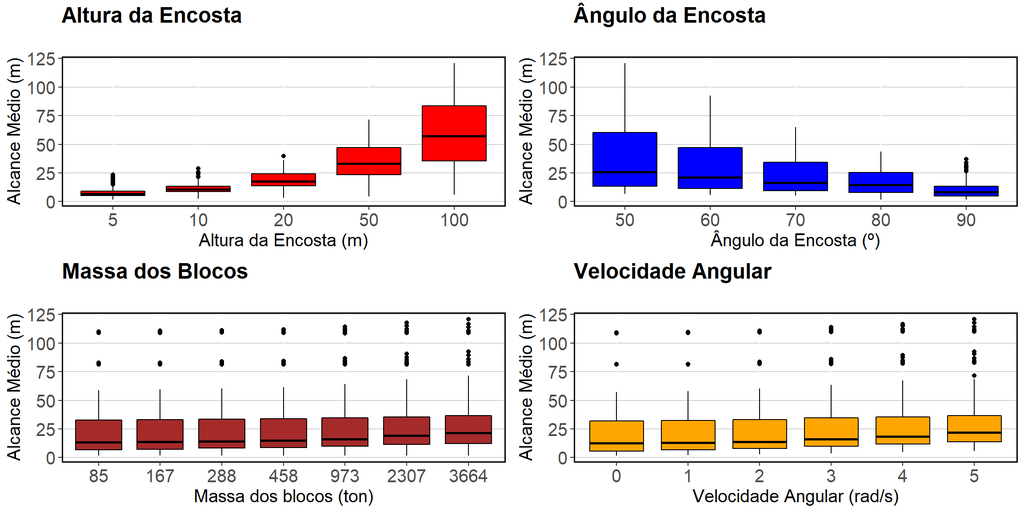

```r
# Boxplot relacionando Alcance com variaveis

    ## 1 - Alturas

    bxp_h <- ggplot(data = df_rcf, aes(x = as.factor(h_enc), y = mean_range)) +
      ggplot2::geom_boxplot(colour = 'black', fill = 'red') +
      ggplot2::xlab('Altura da Encosta (m)') +
      ggplot2::ylab('Alcance Médio (m)') +
      ggplot2::labs(title = "Altura da Encosta\n") +
      ggplot2::theme(panel.background = element_rect(fill = "white"),
                     panel.grid.major.y =  element_line(colour = "lightgrey"),
                     #panel.grid.major.x =  element_line(colour = "lightgrey"),
                     plot.title = element_text(size = 18.0, face = "bold"),
                     panel.border = element_rect(colour = "black", fill = NA, size = 1),
                     axis.text.x = element_text(angle = 0, size = 15.0),
                     axis.text.y = element_text(size = 15.0),
                     axis.title.x = element_text(size = 15.0),
                     axis.title.y = element_text(size = 15.0))

    ## 2 - Angulos

    bxp_ang <- ggplot(data = df_rcf, aes(x = as.factor(ang_enc), y = mean_range)) +
      ggplot2::geom_boxplot(colour = 'black', fill = 'blue') +
      ggplot2::xlab('Ângulo da Encosta (º)') +
      ggplot2::ylab('Alcance Médio (m)') +
      ggplot2::labs(title = "Ângulo da Encosta\n") +
      ggplot2::theme(panel.background = element_rect(fill = "white"),
                     panel.grid.major.y =  element_line(colour = "lightgrey"),
                     #panel.grid.major.x =  element_line(colour = "lightgrey"),
                     plot.title = element_text(size = 18, face = "bold"),
                     panel.border = element_rect(colour = "black", fill = NA, size = 1),
                     axis.text.x = element_text(angle = 0, size = 15.0),
                     axis.text.y = element_text(size = 15.0),
                     axis.title.x = element_text(size = 15.0),
                     axis.title.y = element_text(size = 15.0))

    ## 3 - Massa dos Blocos

    bxp_mass <- ggplot(data = df_rcf, aes(x = as.factor(rock_mass/1000.00), y = mean_range)) +
      ggplot2::geom_boxplot(colour = 'black', fill = 'brown') +
      ggplot2::xlab('Massa dos blocos (ton)') +
      ggplot2::ylab('Alcance Médio (m)') +
      ggplot2::labs(title = "Massa dos Blocos\n") +
      ggplot2::theme(panel.background = element_rect(fill = "white"),
                     panel.grid.major.y =  element_line(colour = "lightgrey"),
                     #panel.grid.major.x =  element_line(colour = "lightgrey"),
                     plot.title = element_text(size = 18, face = "bold"),
                     panel.border = element_rect(colour = "black", fill = NA, size = 1),
                     axis.text.x = element_text(angle = 0, size = 15.0),
                     axis.text.y = element_text(size = 15.0),
                     axis.title.x = element_text(size = 15.0),
                     axis.title.y = element_text(size = 15.0))

    ## 4 - Velocidade Angular

    bxp_vel <- ggplot(data = df_rcf, aes(x = as.factor(vel_rad), y = mean_range)) +
      ggplot2::geom_boxplot(colour = 'black', fill = 'orange') +
      ggplot2::xlab('Velocidade Angular (rad/s)') +
      ggplot2::ylab('Alcance Médio (m)') +
      ggplot2::labs(title = "Velocidade Angular\n") +
      ggplot2::theme(panel.background = element_rect(fill = "white"),
                     panel.grid.major.y =  element_line(colour = "lightgrey"),
                     #panel.grid.major.x =  element_line(colour = "lightgrey"),
                     plot.title = element_text(size = 18, face = "bold"),
                     panel.border = element_rect(colour = "black", fill = NA, size = 1),
                     axis.text.x = element_text(angle = 0, size = 15.0),
                     axis.text.y = element_text(size = 15.0),
                     axis.title.x = element_text(size = 15.0),
                     axis.title.y = element_text(size = 15.0))


# Colocando todos os plots em um grid para visualizacao unica

gridExtra::grid.arrange(bxp_h, bxp_ang,
                        bxp_mass, bxp_vel,
                        ncol = 2, nrow = 2)
```

*Comments*: Os graficos comprovam o corrplot, comparando mean_range pelas demais variaveis!

## 3.5 . **Correlação Numérica - Alcance x Velocidade Angular**

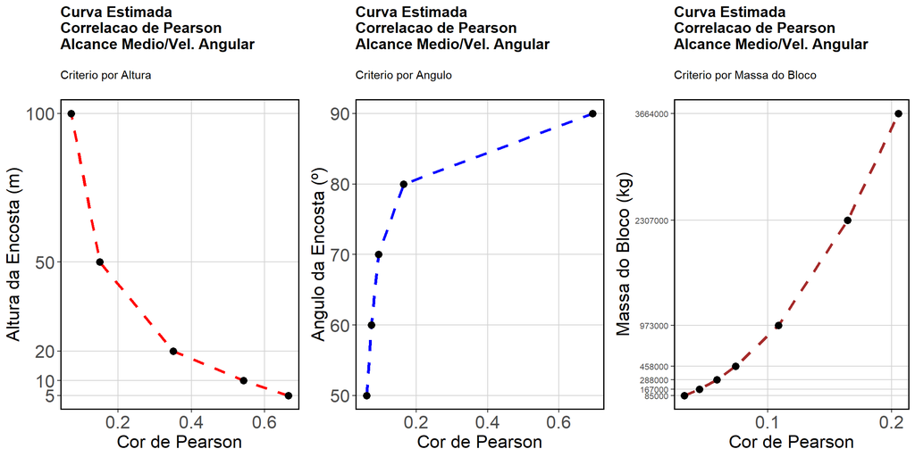

```r
# Correlacoes de Pearson Alcance/Velocidade Angular

  ## 1 - Alturas

  df_corr_hs <- df_rcf %>%
    dplyr::group_by(h_enc) %>%
    dplyr::summarise(corr_hs = stats::cor(mean_range, vel_rad))
    ### A relação entre as variáveis vai diminuindo a medida que a altura aumenta

        ### Verificando a disposição em um Grafico de pontos e a possivel curva:

        gg_h <- ggplot2::ggplot(data = df_corr_hs, aes(x = corr_hs, y = h_enc)) +
          ggplot2::geom_path(linetype = 'dashed', colour = 'red', size = 1.25) +
          ggplot2::geom_point(colour = 'black', size = 3.0, shape = 19) +
          ggplot2::labs(title = "Curva Estimada\nCorrelacao de Pearson\nAlcance Medio/Vel. Angular",
                        subtitle = "\nCriterio por Altura\n") +
          ggplot2::scale_x_continuous("Cor de Pearson", breaks = seq(0.0, 1.0, by = 0.2)) +
          ggplot2::scale_y_continuous("Altura da Encosta (m)", breaks = unique(df_corr_hs$h_enc)) +
          ggplot2::theme(panel.background = element_rect(fill = "white"),
                         axis.text.x = element_text(angle = 0, size = 17.0),
                         axis.text.y = element_text(size = 17.0),
                         axis.title.x = element_text(size = 17.0),
                         axis.title.y = element_text(size = 17.0),
                         panel.grid.major.y =  element_line(colour = "lightgrey"),
                         panel.grid.major.x =  element_line(colour = "lightgrey"),
                         plot.title = element_text(size = 14, face = "bold"),
                         panel.border = element_rect(colour = "black", fill = NA, size = 1))

  ## 2 - Angulo da Encosta

  df_corr_ang <- df_rcf %>%
    dplyr::group_by(ang_enc) %>%
    dplyr::summarise(corr_ang = stats::cor(mean_range, vel_rad))
        ### A relação entre as variáveis vai aumentando a medida que a altura aumenta

        ### Verificando a disposição em um Grafico de pontos e a possivel curva:

        gg_ang <- ggplot2::ggplot(data = df_corr_ang, aes(x = corr_ang, y = ang_enc)) +
          ggplot2::geom_path(linetype = 'dashed', colour = 'blue', size = 1.25) +
          ggplot2::geom_point(colour = 'black', size = 3.0, shape = 19) +
          ggplot2::labs(title = "Curva Estimada\nCorrelacao de Pearson\nAlcance Medio/Vel. Angular",
                        subtitle = "\nCriterio por Angulo\n") +
          ggplot2::scale_x_continuous("Cor de Pearson", breaks = seq(0.0, 1.0, by = 0.2)) +
          ggplot2::scale_y_continuous("Angulo da Encosta (º)", breaks = unique(df_corr_ang$ang_enc)) +
          theme(panel.background = element_rect(fill = "white"),
                axis.text.x = element_text(angle = 0, size = 17.0),
                axis.text.y = element_text(size = 17.0),
                axis.title.x = element_text(size = 17.0),
                axis.title.y = element_text(size = 17.0),
                panel.grid.major.y =  element_line(colour = "lightgrey"),
                panel.grid.major.x =  element_line(colour = "lightgrey"),
                plot.title = element_text(size = 14, face = "bold"),
                panel.border = element_rect(colour = "black", fill = NA, size = 1))

  ## 3 - Massa do Bloco

  df_corr_mass <- df_rcf %>%
    dplyr::group_by(rock_mass) %>%
    dplyr::summarise(corr_mass = stats::cor(mean_range, vel_rad))
      ### A relação entre as variáveis vai aumentando a medida que a
      ### massa do bloco aumenta, mas ainda permanece muito baixo!

        ### Verificando a disposição em um Grafico de pontos e a possivel curva:

        gg_mass <- ggplot2::ggplot(data = df_corr_mass, aes(x = corr_mass, y = rock_mass)) +
          ggplot2::geom_path(linetype = 'dashed', colour = 'brown', size = 1.25) +
          ggplot2::geom_point(colour = 'black', size = 3.0, shape = 19) +
          ggplot2::labs(title = "Curva Estimada\nCorrelacao de Pearson\nAlcance Medio/Vel. Angular",
                        subtitle = "\nCriterio por Massa do Bloco\n") +
          ggplot2::scale_x_continuous("Cor de Pearson", breaks = seq(0.0, 1.0, by = 0.1)) +
          ggplot2::scale_y_continuous("Massa do Bloco (kg)", breaks = unique(df_corr_mass$rock_mass)) +
          theme(panel.background = element_rect(fill = "white"),
                axis.text.x = element_text(angle = 0, size = 17.0),
                axis.text.y = element_text(size = 8.0),
                axis.title.x = element_text(size = 17.0),
                axis.title.y = element_text(size = 17.0),
                panel.grid.major.y =  element_line(colour = "lightgrey"),
                panel.grid.major.x =  element_line(colour = "lightgrey"),
                plot.title = element_text(size = 14, face = "bold"),
                panel.border = element_rect(colour = "black", fill = NA, size = 1))


# Plot de todos os graficos unidos

gridExtra::grid.arrange(gg_h, gg_ang, gg_mass,
                        ncol = 3, nrow = 1)
```

## 3.6 . **Salvando base para modelo**

```r
# Salvando dado para estudo futuro

data.table::fwrite(
  x = df_rcf,
  file = 'C:/Users/daiha/OneDrive/Desktop/UFRJ/IC_Emilio/Resultados/ic_rocfall/TCC_files/df_rcf.gz',
  compress = 'gzip')

# Limpando workspace

rm(list = ls())
```